# Risk Factor Analysis

## Outcome Variable

**Outcome Variable:** sstunted

## Predictor Variables

**Intervention Variable:** month

**Adjustment Set:**

unadjusted

## Stratifying Variables

The analysis was stratified on these variable(s):

- agecat
- studyid
- country

## Data Summary

| agecat | studyid | country | A | n | nA | nAY0 | nAY1 |
| --- | --- | --- | --- | --- | --- | --- | --- |
| Birth | ki0047075b-MAL-ED | BANGLADESH | 1 | 257 | 19 | 19 | 0 |
| Birth | ki0047075b-MAL-ED | BANGLADESH | 2 | 257 | 24 | 23 | 1 |
| Birth | ki0047075b-MAL-ED | BANGLADESH | 3 | 257 | 28 | 28 | 0 |
| Birth | ki0047075b-MAL-ED | BANGLADESH | 4 | 257 | 21 | 21 | 0 |
| Birth | ki0047075b-MAL-ED | BANGLADESH | 5 | 257 | 21 | 19 | 2 |
| Birth | ki0047075b-MAL-ED | BANGLADESH | 6 | 257 | 9 | 9 | 0 |
| Birth | ki0047075b-MAL-ED | BANGLADESH | 7 | 257 | 22 | 21 | 1 |
| Birth | ki0047075b-MAL-ED | BANGLADESH | 8 | 257 | 25 | 22 | 3 |
| Birth | ki0047075b-MAL-ED | BANGLADESH | 9 | 257 | 22 | 21 | 1 |
| Birth | ki0047075b-MAL-ED | BANGLADESH | 10 | 257 | 24 | 24 | 0 |
| Birth | ki0047075b-MAL-ED | BANGLADESH | 11 | 257 | 15 | 15 | 0 |
| Birth | ki0047075b-MAL-ED | BANGLADESH | 12 | 257 | 27 | 26 | 1 |
| Birth | ki0047075b-MAL-ED | BRAZIL | 1 | 191 | 9 | 9 | 0 |
| Birth | ki0047075b-MAL-ED | BRAZIL | 2 | 191 | 21 | 19 | 2 |
| Birth | ki0047075b-MAL-ED | BRAZIL | 3 | 191 | 18 | 17 | 1 |
| Birth | ki0047075b-MAL-ED | BRAZIL | 4 | 191 | 8 | 8 | 0 |
| Birth | ki0047075b-MAL-ED | BRAZIL | 5 | 191 | 19 | 17 | 2 |
| Birth | ki0047075b-MAL-ED | BRAZIL | 6 | 191 | 7 | 7 | 0 |
| Birth | ki0047075b-MAL-ED | BRAZIL | 7 | 191 | 17 | 16 | 1 |
| Birth | ki0047075b-MAL-ED | BRAZIL | 8 | 191 | 18 | 18 | 0 |
| Birth | ki0047075b-MAL-ED | BRAZIL | 9 | 191 | 28 | 26 | 2 |
| Birth | ki0047075b-MAL-ED | BRAZIL | 10 | 191 | 18 | 18 | 0 |
| Birth | ki0047075b-MAL-ED | BRAZIL | 11 | 191 | 15 | 15 | 0 |
| Birth | ki0047075b-MAL-ED | BRAZIL | 12 | 191 | 13 | 13 | 0 |
| Birth | ki0047075b-MAL-ED | INDIA | 1 | 206 | 16 | 16 | 0 |
| Birth | ki0047075b-MAL-ED | INDIA | 2 | 206 | 16 | 16 | 0 |
| Birth | ki0047075b-MAL-ED | INDIA | 3 | 206 | 20 | 20 | 0 |
| Birth | ki0047075b-MAL-ED | INDIA | 4 | 206 | 15 | 14 | 1 |
| Birth | ki0047075b-MAL-ED | INDIA | 5 | 206 | 7 | 7 | 0 |
| Birth | ki0047075b-MAL-ED | INDIA | 6 | 206 | 17 | 17 | 0 |

[output cut: 1746 more lines]

The following strata were considered:

- agecat: 12 months, studyid: ki0047075b-MAL-ED, country: BANGLADESH
- agecat: 12 months, studyid: ki0047075b-MAL-ED, country: BRAZIL
- agecat: 12 months, studyid: ki0047075b-MAL-ED, country: INDIA
- agecat: 12 months, studyid: ki0047075b-MAL-ED, country: NEPAL
- agecat: 12 months, studyid: ki0047075b-MAL-ED, country: PERU
- agecat: 12 months, studyid: ki0047075b-MAL-ED, country: SOUTH AFRICA
- agecat: 12 months, studyid: ki0047075b-MAL-ED, country: TANZANIA, UNITED REPUBLIC OF
- agecat: 12 months, studyid: ki1000108-CMC-V-BCS-2002, country: INDIA
- agecat: 12 months, studyid: ki1000108-IRC, country: INDIA
- agecat: 12 months, studyid: ki1000109-EE, country: PAKISTAN
- agecat: 12 months, studyid: ki1000109-ResPak, country: PAKISTAN
- agecat: 12 months, studyid: ki1000304b-SAS-FoodSuppl, country: INDIA
- agecat: 12 months, studyid: ki1017093-NIH-Birth, country: BANGLADESH
- agecat: 12 months, studyid: ki1066203-TanzaniaChild2, country: TANZANIA, UNITED REPUBLIC OF
- agecat: 12 months, studyid: ki1112895-Guatemala BSC, country: GUATEMALA
- agecat: 12 months, studyid: ki1113344-GMS-Nepal, country: NEPAL
- agecat: 12 months, studyid: ki1114097-CMIN, country: BANGLADESH
- agecat: 12 months, studyid: ki1114097-CMIN, country: BRAZIL
- agecat: 12 months, studyid: ki1114097-CMIN, country: GUINEA-BISSAU
- agecat: 12 months, studyid: ki1114097-CMIN, country: PERU
- agecat: 12 months, studyid: ki1114097-CONTENT, country: PERU
- agecat: 12 months, studyid: ki1126311-ZVITAMBO, country: ZIMBABWE
- agecat: 12 months, studyid: ki1148112-LCNI-5, country: MALAWI
- agecat: 18 months, studyid: ki0047075b-MAL-ED, country: BANGLADESH
- agecat: 18 months, studyid: ki0047075b-MAL-ED, country: BRAZIL
- agecat: 18 months, studyid: ki0047075b-MAL-ED, country: INDIA
- agecat: 18 months, studyid: ki0047075b-MAL-ED, country: NEPAL
- agecat: 18 months, studyid: ki0047075b-MAL-ED, country: PERU
- agecat: 18 months, studyid: ki0047075b-MAL-ED, country: SOUTH AFRICA
- agecat: 18 months, studyid: ki0047075b-MAL-ED, country: TANZANIA, UNITED REPUBLIC OF
- agecat: 18 months, studyid: ki1000108-CMC-V-BCS-2002, country: INDIA
- agecat: 18 months, studyid: ki1000108-IRC, country: INDIA
- agecat: 18 months, studyid: ki1000109-EE, country: PAKISTAN
- agecat: 18 months, studyid: ki1000109-ResPak, country: PAKISTAN
- agecat: 18 months, studyid: ki1000304b-SAS-FoodSuppl, country: INDIA
- agecat: 18 months, studyid: ki1017093-NIH-Birth, country: BANGLADESH
- agecat: 18 months, studyid: ki1066203-TanzaniaChild2, country: TANZANIA, UNITED REPUBLIC OF
- agecat: 18 months, studyid: ki1113344-GMS-Nepal, country: NEPAL
- agecat: 18 months, studyid: ki1114097-CMIN, country: BANGLADESH
- agecat: 18 months, studyid: ki1114097-CMIN, country: BRAZIL
- agecat: 18 months, studyid: ki1114097-CMIN, country: GUINEA-BISSAU
- agecat: 18 months, studyid: ki1114097-CMIN, country: PERU
- agecat: 18 months, studyid: ki1114097-CONTENT, country: PERU
- agecat: 18 months, studyid: ki1126311-ZVITAMBO, country: ZIMBABWE
- agecat: 18 months, studyid: ki1148112-LCNI-5, country: MALAWI
- agecat: 24 months, studyid: ki0047075b-MAL-ED, country: BANGLADESH
- agecat: 24 months, studyid: ki0047075b-MAL-ED, country: BRAZIL
- agecat: 24 months, studyid: ki0047075b-MAL-ED, country: INDIA
- agecat: 24 months, studyid: ki0047075b-MAL-ED, country: NEPAL
- agecat: 24 months, studyid: ki0047075b-MAL-ED, country: PERU
- agecat: 24 months, studyid: ki0047075b-MAL-ED, country: SOUTH AFRICA
- agecat: 24 months, studyid: ki0047075b-MAL-ED, country: TANZANIA, UNITED REPUBLIC OF
- agecat: 24 months, studyid: ki1000108-CMC-V-BCS-2002, country: INDIA
- agecat: 24 months, studyid: ki1000108-IRC, country: INDIA
- agecat: 24 months, studyid: ki1017093-NIH-Birth, country: BANGLADESH
- agecat: 24 months, studyid: ki1066203-TanzaniaChild2, country: TANZANIA, UNITED REPUBLIC OF
- agecat: 24 months, studyid: ki1113344-GMS-Nepal, country: NEPAL
- agecat: 24 months, studyid: ki1114097-CMIN, country: BANGLADESH
- agecat: 24 months, studyid: ki1114097-CMIN, country: GUINEA-BISSAU
- agecat: 24 months, studyid: ki1114097-CMIN, country: PERU
- agecat: 24 months, studyid: ki1114097-CONTENT, country: PERU
- agecat: 24 months, studyid: ki1126311-ZVITAMBO, country: ZIMBABWE
- agecat: 24 months, studyid: ki1148112-LCNI-5, country: MALAWI
- agecat: 3 months, studyid: ki0047075b-MAL-ED, country: BANGLADESH
- agecat: 3 months, studyid: ki0047075b-MAL-ED, country: BRAZIL
- agecat: 3 months, studyid: ki0047075b-MAL-ED, country: INDIA
- agecat: 3 months, studyid: ki0047075b-MAL-ED, country: NEPAL
- agecat: 3 months, studyid: ki0047075b-MAL-ED, country: PERU
- agecat: 3 months, studyid: ki0047075b-MAL-ED, country: SOUTH AFRICA
- agecat: 3 months, studyid: ki0047075b-MAL-ED, country: TANZANIA, UNITED REPUBLIC OF
- agecat: 3 months, studyid: ki1000108-CMC-V-BCS-2002, country: INDIA
- agecat: 3 months, studyid: ki1000108-IRC, country: INDIA
- agecat: 3 months, studyid: ki1000109-EE, country: PAKISTAN
- agecat: 3 months, studyid: ki1000109-ResPak, country: PAKISTAN
- agecat: 3 months, studyid: ki1000304b-SAS-FoodSuppl, country: INDIA
- agecat: 3 months, studyid: ki1017093-NIH-Birth, country: BANGLADESH
- agecat: 3 months, studyid: ki1066203-TanzaniaChild2, country: TANZANIA, UNITED REPUBLIC OF
- agecat: 3 months, studyid: ki1112895-Guatemala BSC, country: GUATEMALA
- agecat: 3 months, studyid: ki1113344-GMS-Nepal, country: NEPAL
- agecat: 3 months, studyid: ki1114097-CMIN, country: BANGLADESH
- agecat: 3 months, studyid: ki1114097-CMIN, country: BRAZIL
- agecat: 3 months, studyid: ki1114097-CMIN, country: GUINEA-BISSAU
- agecat: 3 months, studyid: ki1114097-CMIN, country: PERU
- agecat: 3 months, studyid: ki1114097-CONTENT, country: PERU
- agecat: 3 months, studyid: ki1126311-ZVITAMBO, country: ZIMBABWE
- agecat: 6 months, studyid: ki0047075b-MAL-ED, country: BANGLADESH
- agecat: 6 months, studyid: ki0047075b-MAL-ED, country: BRAZIL
- agecat: 6 months, studyid: ki0047075b-MAL-ED, country: INDIA
- agecat: 6 months, studyid: ki0047075b-MAL-ED, country: NEPAL
- agecat: 6 months, studyid: ki0047075b-MAL-ED, country: PERU
- agecat: 6 months, studyid: ki0047075b-MAL-ED, country: SOUTH AFRICA
- agecat: 6 months, studyid: ki0047075b-MAL-ED, country: TANZANIA, UNITED REPUBLIC OF
- agecat: 6 months, studyid: ki1000108-CMC-V-BCS-2002, country: INDIA
- agecat: 6 months, studyid: ki1000108-IRC, country: INDIA
- agecat: 6 months, studyid: ki1000109-EE, country: PAKISTAN
- agecat: 6 months, studyid: ki1000109-ResPak, country: PAKISTAN
- agecat: 6 months, studyid: ki1000304b-SAS-FoodSuppl, country: INDIA
- agecat: 6 months, studyid: ki1017093-NIH-Birth, country: BANGLADESH
- agecat: 6 months, studyid: ki1066203-TanzaniaChild2, country: TANZANIA, UNITED REPUBLIC OF
- agecat: 6 months, studyid: ki1112895-Guatemala BSC, country: GUATEMALA
- agecat: 6 months, studyid: ki1113344-GMS-Nepal, country: NEPAL
- agecat: 6 months, studyid: ki1114097-CMIN, country: BANGLADESH
- agecat: 6 months, studyid: ki1114097-CMIN, country: BRAZIL
- agecat: 6 months, studyid: ki1114097-CMIN, country: GUINEA-BISSAU
- agecat: 6 months, studyid: ki1114097-CMIN, country: PERU
- agecat: 6 months, studyid: ki1114097-CONTENT, country: PERU
- agecat: 6 months, studyid: ki1126311-ZVITAMBO, country: ZIMBABWE
- agecat: 6 months, studyid: ki1148112-LCNI-5, country: MALAWI
- agecat: 9 months, studyid: ki0047075b-MAL-ED, country: BANGLADESH
- agecat: 9 months, studyid: ki0047075b-MAL-ED, country: BRAZIL
- agecat: 9 months, studyid: ki0047075b-MAL-ED, country: INDIA
- agecat: 9 months, studyid: ki0047075b-MAL-ED, country: NEPAL
- agecat: 9 months, studyid: ki0047075b-MAL-ED, country: PERU
- agecat: 9 months, studyid: ki0047075b-MAL-ED, country: SOUTH AFRICA
- agecat: 9 months, studyid: ki0047075b-MAL-ED, country: TANZANIA, UNITED REPUBLIC OF
- agecat: 9 months, studyid: ki1000108-CMC-V-BCS-2002, country: INDIA
- agecat: 9 months, studyid: ki1000108-IRC, country: INDIA
- agecat: 9 months, studyid: ki1000109-EE, country: PAKISTAN
- agecat: 9 months, studyid: ki1000109-ResPak, country: PAKISTAN
- agecat: 9 months, studyid: ki1000304b-SAS-FoodSuppl, country: INDIA
- agecat: 9 months, studyid: ki1017093-NIH-Birth, country: BANGLADESH
- agecat: 9 months, studyid: ki1066203-TanzaniaChild2, country: TANZANIA, UNITED REPUBLIC OF
- agecat: 9 months, studyid: ki1112895-Guatemala BSC, country: GUATEMALA
- agecat: 9 months, studyid: ki1113344-GMS-Nepal, country: NEPAL
- agecat: 9 months, studyid: ki1114097-CMIN, country: BANGLADESH
- agecat: 9 months, studyid: ki1114097-CMIN, country: BRAZIL
- agecat: 9 months, studyid: ki1114097-CMIN, country: GUINEA-BISSAU
- agecat: 9 months, studyid: ki1114097-CMIN, country: PERU
- agecat: 9 months, studyid: ki1114097-CONTENT, country: PERU
- agecat: 9 months, studyid: ki1126311-ZVITAMBO, country: ZIMBABWE
- agecat: 9 months, studyid: ki1148112-LCNI-5, country: MALAWI
- agecat: Birth, studyid: ki0047075b-MAL-ED, country: BANGLADESH
- agecat: Birth, studyid: ki0047075b-MAL-ED, country: BRAZIL
- agecat: Birth, studyid: ki0047075b-MAL-ED, country: INDIA
- agecat: Birth, studyid: ki0047075b-MAL-ED, country: NEPAL
- agecat: Birth, studyid: ki0047075b-MAL-ED, country: PERU
- agecat: Birth, studyid: ki0047075b-MAL-ED, country: SOUTH AFRICA
- agecat: Birth, studyid: ki0047075b-MAL-ED, country: TANZANIA, UNITED REPUBLIC OF
- agecat: Birth, studyid: ki1000108-CMC-V-BCS-2002, country: INDIA
- agecat: Birth, studyid: ki1000108-IRC, country: INDIA
- agecat: Birth, studyid: ki1000109-EE, country: PAKISTAN
- agecat: Birth, studyid: ki1000109-ResPak, country: PAKISTAN
- agecat: Birth, studyid: ki1017093-NIH-Birth, country: BANGLADESH
- agecat: Birth, studyid: ki1114097-CMIN, country: BANGLADESH
- agecat: Birth, studyid: ki1114097-CMIN, country: BRAZIL
- agecat: Birth, studyid: ki1114097-CMIN, country: PERU
- agecat: Birth, studyid: ki1114097-CONTENT, country: PERU
- agecat: Birth, studyid: ki1126311-ZVITAMBO, country: ZIMBABWE

### Dropped Strata

Some strata were dropped due to rare outcomes:

- agecat: Birth, studyid: ki0047075b-MAL-ED, country: BANGLADESH
- agecat: Birth, studyid: ki0047075b-MAL-ED, country: BRAZIL
- agecat: Birth, studyid: ki0047075b-MAL-ED, country: INDIA
- agecat: Birth, studyid: ki0047075b-MAL-ED, country: NEPAL
- agecat: Birth, studyid: ki0047075b-MAL-ED, country: PERU
- agecat: Birth, studyid: ki0047075b-MAL-ED, country: SOUTH AFRICA
- agecat: Birth, studyid: ki0047075b-MAL-ED, country: TANZANIA, UNITED REPUBLIC OF
- agecat: Birth, studyid: ki1000108-CMC-V-BCS-2002, country: INDIA
- agecat: Birth, studyid: ki1000108-IRC, country: INDIA
- agecat: Birth, studyid: ki1000109-EE, country: PAKISTAN
- agecat: Birth, studyid: ki1000109-ResPak, country: PAKISTAN
- agecat: Birth, studyid: ki1017093-NIH-Birth, country: BANGLADESH
- agecat: Birth, studyid: ki1114097-CMIN, country: BANGLADESH
- agecat: Birth, studyid: ki1114097-CMIN, country: BRAZIL
- agecat: Birth, studyid: ki1114097-CMIN, country: PERU
- agecat: Birth, studyid: ki1114097-CONTENT, country: PERU
- agecat: 3 months, studyid: ki0047075b-MAL-ED, country: BANGLADESH
- agecat: 3 months, studyid: ki0047075b-MAL-ED, country: BRAZIL
- agecat: 3 months, studyid: ki0047075b-MAL-ED, country: INDIA
- agecat: 3 months, studyid: ki0047075b-MAL-ED, country: NEPAL
- agecat: 3 months, studyid: ki0047075b-MAL-ED, country: PERU
- agecat: 3 months, studyid: ki0047075b-MAL-ED, country: SOUTH AFRICA
- agecat: 3 months, studyid: ki0047075b-MAL-ED, country: TANZANIA, UNITED REPUBLIC OF
- agecat: 3 months, studyid: ki1000108-CMC-V-BCS-2002, country: INDIA
- agecat: 3 months, studyid: ki1000108-IRC, country: INDIA
- agecat: 3 months, studyid: ki1000109-EE, country: PAKISTAN
- agecat: 3 months, studyid: ki1000109-ResPak, country: PAKISTAN
- agecat: 3 months, studyid: ki1000304b-SAS-FoodSuppl, country: INDIA
- agecat: 3 months, studyid: ki1017093-NIH-Birth, country: BANGLADESH
- agecat: 3 months, studyid: ki1066203-TanzaniaChild2, country: TANZANIA, UNITED REPUBLIC OF
- agecat: 3 months, studyid: ki1112895-Guatemala BSC, country: GUATEMALA
- agecat: 3 months, studyid: ki1113344-GMS-Nepal, country: NEPAL
- agecat: 3 months, studyid: ki1114097-CMIN, country: BANGLADESH
- agecat: 3 months, studyid: ki1114097-CMIN, country: BRAZIL
- agecat: 3 months, studyid: ki1114097-CMIN, country: GUINEA-BISSAU
- agecat: 3 months, studyid: ki1114097-CMIN, country: PERU
- agecat: 3 months, studyid: ki1114097-CONTENT, country: PERU
- agecat: 6 months, studyid: ki0047075b-MAL-ED, country: BANGLADESH
- agecat: 6 months, studyid: ki0047075b-MAL-ED, country: BRAZIL
- agecat: 6 months, studyid: ki0047075b-MAL-ED, country: INDIA
- agecat: 6 months, studyid: ki0047075b-MAL-ED, country: NEPAL
- agecat: 6 months, studyid: ki0047075b-MAL-ED, country: PERU
- agecat: 6 months, studyid: ki0047075b-MAL-ED, country: SOUTH AFRICA
- agecat: 6 months, studyid: ki0047075b-MAL-ED, country: TANZANIA, UNITED REPUBLIC OF
- agecat: 6 months, studyid: ki1000108-CMC-V-BCS-2002, country: INDIA
- agecat: 6 months, studyid: ki1000108-IRC, country: INDIA
- agecat: 6 months, studyid: ki1000109-EE, country: PAKISTAN
- agecat: 6 months, studyid: ki1000109-ResPak, country: PAKISTAN
- agecat: 6 months, studyid: ki1000304b-SAS-FoodSuppl, country: INDIA
- agecat: 6 months, studyid: ki1017093-NIH-Birth, country: BANGLADESH
- agecat: 6 months, studyid: ki1066203-TanzaniaChild2, country: TANZANIA, UNITED REPUBLIC OF
- agecat: 6 months, studyid: ki1112895-Guatemala BSC, country: GUATEMALA
- agecat: 6 months, studyid: ki1113344-GMS-Nepal, country: NEPAL
- agecat: 6 months, studyid: ki1114097-CMIN, country: BANGLADESH
- agecat: 6 months, studyid: ki1114097-CMIN, country: BRAZIL
- agecat: 6 months, studyid: ki1114097-CMIN, country: GUINEA-BISSAU
- agecat: 6 months, studyid: ki1114097-CMIN, country: PERU
- agecat: 6 months, studyid: ki1114097-CONTENT, country: PERU
- agecat: 6 months, studyid: ki1148112-LCNI-5, country: MALAWI
- agecat: 9 months, studyid: ki0047075b-MAL-ED, country: BANGLADESH
- agecat: 9 months, studyid: ki0047075b-MAL-ED, country: BRAZIL
- agecat: 9 months, studyid: ki0047075b-MAL-ED, country: INDIA
- agecat: 9 months, studyid: ki0047075b-MAL-ED, country: NEPAL
- agecat: 9 months, studyid: ki0047075b-MAL-ED, country: PERU
- agecat: 9 months, studyid: ki0047075b-MAL-ED, country: SOUTH AFRICA
- agecat: 9 months, studyid: ki0047075b-MAL-ED, country: TANZANIA, UNITED REPUBLIC OF
- agecat: 9 months, studyid: ki1000108-CMC-V-BCS-2002, country: INDIA
- agecat: 9 months, studyid: ki1000108-IRC, country: INDIA
- agecat: 9 months, studyid: ki1000109-EE, country: PAKISTAN
- agecat: 9 months, studyid: ki1000109-ResPak, country: PAKISTAN
- agecat: 9 months, studyid: ki1000304b-SAS-FoodSuppl, country: INDIA
- agecat: 9 months, studyid: ki1017093-NIH-Birth, country: BANGLADESH
- agecat: 9 months, studyid: ki1066203-TanzaniaChild2, country: TANZANIA, UNITED REPUBLIC OF
- agecat: 9 months, studyid: ki1112895-Guatemala BSC, country: GUATEMALA
- agecat: 9 months, studyid: ki1113344-GMS-Nepal, country: NEPAL
- agecat: 9 months, studyid: ki1114097-CMIN, country: BANGLADESH
- agecat: 9 months, studyid: ki1114097-CMIN, country: BRAZIL
- agecat: 9 months, studyid: ki1114097-CMIN, country: GUINEA-BISSAU
- agecat: 9 months, studyid: ki1114097-CMIN, country: PERU
- agecat: 9 months, studyid: ki1114097-CONTENT, country: PERU
- agecat: 9 months, studyid: ki1148112-LCNI-5, country: MALAWI
- agecat: 12 months, studyid: ki0047075b-MAL-ED, country: BANGLADESH
- agecat: 12 months, studyid: ki0047075b-MAL-ED, country: BRAZIL
- agecat: 12 months, studyid: ki0047075b-MAL-ED, country: INDIA
- agecat: 12 months, studyid: ki0047075b-MAL-ED, country: NEPAL
- agecat: 12 months, studyid: ki0047075b-MAL-ED, country: PERU
- agecat: 12 months, studyid: ki0047075b-MAL-ED, country: SOUTH AFRICA
- agecat: 12 months, studyid: ki0047075b-MAL-ED, country: TANZANIA, UNITED REPUBLIC OF
- agecat: 12 months, studyid: ki1000108-CMC-V-BCS-2002, country: INDIA
- agecat: 12 months, studyid: ki1000108-IRC, country: INDIA
- agecat: 12 months, studyid: ki1000109-EE, country: PAKISTAN
- agecat: 12 months, studyid: ki1000109-ResPak, country: PAKISTAN
- agecat: 12 months, studyid: ki1000304b-SAS-FoodSuppl, country: INDIA
- agecat: 12 months, studyid: ki1017093-NIH-Birth, country: BANGLADESH
- agecat: 12 months, studyid: ki1066203-TanzaniaChild2, country: TANZANIA, UNITED REPUBLIC OF
- agecat: 12 months, studyid: ki1112895-Guatemala BSC, country: GUATEMALA
- agecat: 12 months, studyid: ki1113344-GMS-Nepal, country: NEPAL
- agecat: 12 months, studyid: ki1114097-CMIN, country: BANGLADESH
- agecat: 12 months, studyid: ki1114097-CMIN, country: BRAZIL
- agecat: 12 months, studyid: ki1114097-CMIN, country: GUINEA-BISSAU
- agecat: 12 months, studyid: ki1114097-CMIN, country: PERU
- agecat: 12 months, studyid: ki1114097-CONTENT, country: PERU
- agecat: 12 months, studyid: ki1148112-LCNI-5, country: MALAWI
- agecat: 18 months, studyid: ki0047075b-MAL-ED, country: BANGLADESH
- agecat: 18 months, studyid: ki0047075b-MAL-ED, country: BRAZIL
- agecat: 18 months, studyid: ki0047075b-MAL-ED, country: INDIA
- agecat: 18 months, studyid: ki0047075b-MAL-ED, country: NEPAL
- agecat: 18 months, studyid: ki0047075b-MAL-ED, country: PERU
- agecat: 18 months, studyid: ki0047075b-MAL-ED, country: SOUTH AFRICA
- agecat: 18 months, studyid: ki0047075b-MAL-ED, country: TANZANIA, UNITED REPUBLIC OF
- agecat: 18 months, studyid: ki1000108-CMC-V-BCS-2002, country: INDIA
- agecat: 18 months, studyid: ki1000108-IRC, country: INDIA
- agecat: 18 months, studyid: ki1000109-EE, country: PAKISTAN
- agecat: 18 months, studyid: ki1000109-ResPak, country: PAKISTAN
- agecat: 18 months, studyid: ki1000304b-SAS-FoodSuppl, country: INDIA
- agecat: 18 months, studyid: ki1017093-NIH-Birth, country: BANGLADESH
- agecat: 18 months, studyid: ki1066203-TanzaniaChild2, country: TANZANIA, UNITED REPUBLIC OF
- agecat: 18 months, studyid: ki1113344-GMS-Nepal, country: NEPAL
- agecat: 18 months, studyid: ki1114097-CMIN, country: BANGLADESH
- agecat: 18 months, studyid: ki1114097-CMIN, country: BRAZIL
- agecat: 18 months, studyid: ki1114097-CMIN, country: GUINEA-BISSAU
- agecat: 18 months, studyid: ki1114097-CMIN, country: PERU
- agecat: 18 months, studyid: ki1114097-CONTENT, country: PERU
- agecat: 18 months, studyid: ki1148112-LCNI-5, country: MALAWI
- agecat: 24 months, studyid: ki0047075b-MAL-ED, country: BANGLADESH
- agecat: 24 months, studyid: ki0047075b-MAL-ED, country: BRAZIL
- agecat: 24 months, studyid: ki0047075b-MAL-ED, country: INDIA
- agecat: 24 months, studyid: ki0047075b-MAL-ED, country: NEPAL
- agecat: 24 months, studyid: ki0047075b-MAL-ED, country: PERU
- agecat: 24 months, studyid: ki0047075b-MAL-ED, country: SOUTH AFRICA
- agecat: 24 months, studyid: ki0047075b-MAL-ED, country: TANZANIA, UNITED REPUBLIC OF
- agecat: 24 months, studyid: ki1000108-CMC-V-BCS-2002, country: INDIA
- agecat: 24 months, studyid: ki1000108-IRC, country: INDIA
- agecat: 24 months, studyid: ki1017093-NIH-Birth, country: BANGLADESH
- agecat: 24 months, studyid: ki1066203-TanzaniaChild2, country: TANZANIA, UNITED REPUBLIC OF
- agecat: 24 months, studyid: ki1113344-GMS-Nepal, country: NEPAL
- agecat: 24 months, studyid: ki1114097-CMIN, country: BANGLADESH
- agecat: 24 months, studyid: ki1114097-CMIN, country: GUINEA-BISSAU
- agecat: 24 months, studyid: ki1114097-CMIN, country: PERU
- agecat: 24 months, studyid: ki1114097-CONTENT, country: PERU
- agecat: 24 months, studyid: ki1126311-ZVITAMBO, country: ZIMBABWE
- agecat: 24 months, studyid: ki1148112-LCNI-5, country: MALAWI

## Methods Detail

We’re interested in the causal parameters $E[Y_a]$ for all values of $a \in \mathcal{A}$. These parameters represent the mean outcome if, possibly contrary to fact, we intervened to set all units to have $A=a$. Under the randomization and positivity assumptions, these are identified by the statistical parameters $\psi_a=E_W[E_{Y|A,W}(Y|A=a,W)]$. In addition, we’re interested in the mean of $Y$, $E[Y]$ under no intervention (the observed mean). We will estimate these parameters by using SuperLearner to fit the relevant likelihood factors – $E_{Y|A,W}(Y|A=a,W)$ and $p(A=a|W)$, and then updating our likelihood fit using a joint TMLE.

For unadjusted analyses ($W=\{\}$), initial likelihoods were estimated using Lrnr_glm to estimate the simple $E(Y|A)$ and Lrnr_mean to estimate $p(A)$. For adjusted analyses, a small library containing Lrnr_glmnet, Lrnr_xgboost, and Lrnr_mean was used.

Having estimated these parameters, we will then use the delta method to estimate relative risks and attributable risks relative to a prespecified baseline level of $A$.

# Results Detail

## Results Plots

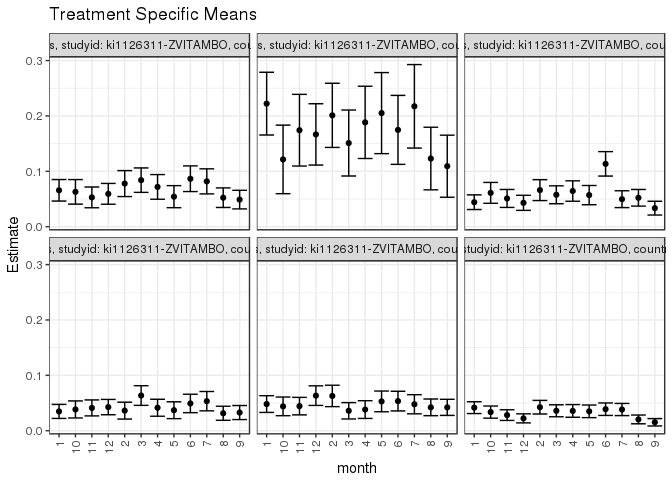

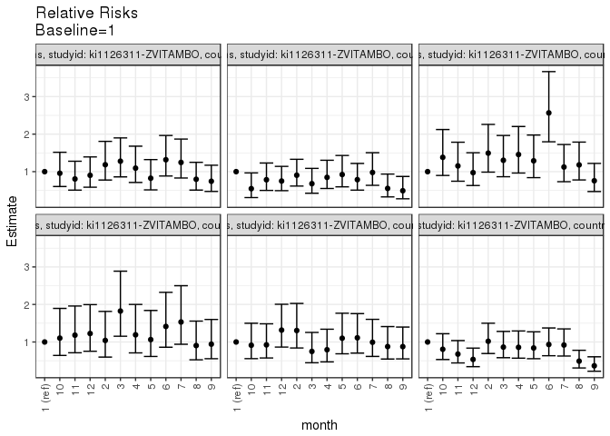

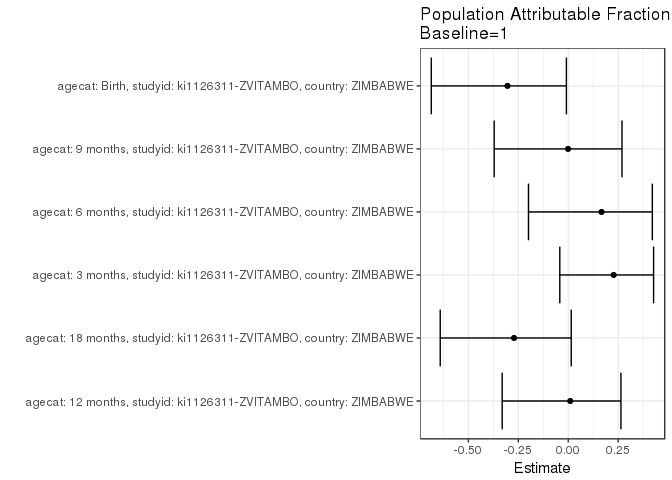

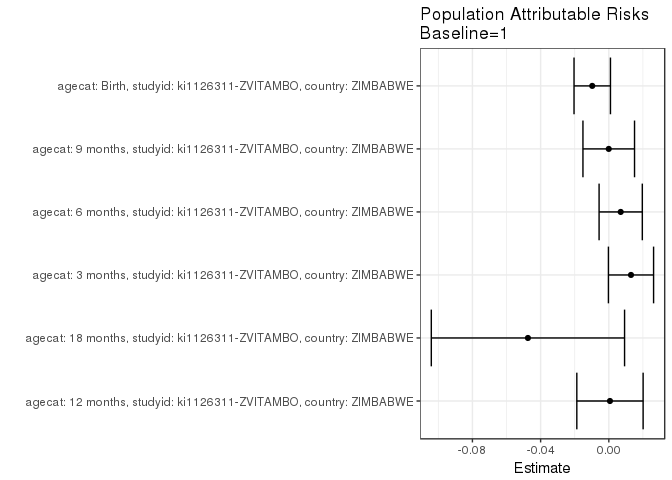

## Results Table

### Parameter: TSM

| agecat | studyid | country | intervention_level | baseline_level | estimate | ci_lower | ci_upper |
| --- | --- | --- | --- | --- | --- | --- | --- |
| Birth | ki1126311-ZVITAMBO | ZIMBABWE | 1 | NA | 0.0416667 | 0.0309831 | 0.0523502 |
| Birth | ki1126311-ZVITAMBO | ZIMBABWE | 2 | NA | 0.0424710 | 0.0301908 | 0.0547513 |
| Birth | ki1126311-ZVITAMBO | ZIMBABWE | 3 | NA | 0.0359649 | 0.0251556 | 0.0467742 |
| Birth | ki1126311-ZVITAMBO | ZIMBABWE | 4 | NA | 0.0357498 | 0.0242819 | 0.0472176 |
| Birth | ki1126311-ZVITAMBO | ZIMBABWE | 5 | NA | 0.0350000 | 0.0236090 | 0.0463910 |
| Birth | ki1126311-ZVITAMBO | ZIMBABWE | 6 | NA | 0.0388693 | 0.0276093 | 0.0501292 |
| Birth | ki1126311-ZVITAMBO | ZIMBABWE | 7 | NA | 0.0382653 | 0.0273008 | 0.0492298 |
| Birth | ki1126311-ZVITAMBO | ZIMBABWE | 8 | NA | 0.0203915 | 0.0124798 | 0.0283032 |
| Birth | ki1126311-ZVITAMBO | ZIMBABWE | 9 | NA | 0.0152323 | 0.0086074 | 0.0218572 |
| Birth | ki1126311-ZVITAMBO | ZIMBABWE | 10 | NA | 0.0335893 | 0.0226494 | 0.0445291 |
| Birth | ki1126311-ZVITAMBO | ZIMBABWE | 11 | NA | 0.0282187 | 0.0185802 | 0.0378572 |
| Birth | ki1126311-ZVITAMBO | ZIMBABWE | 12 | NA | 0.0223108 | 0.0141393 | 0.0304822 |
| 3 months | ki1126311-ZVITAMBO | ZIMBABWE | 1 | NA | 0.0442287 | 0.0309926 | 0.0574648 |
| 3 months | ki1126311-ZVITAMBO | ZIMBABWE | 2 | NA | 0.0660661 | 0.0472000 | 0.0849322 |
| 3 months | ki1126311-ZVITAMBO | ZIMBABWE | 3 | NA | 0.0576441 | 0.0414724 | 0.0738158 |
| 3 months | ki1126311-ZVITAMBO | ZIMBABWE | 4 | NA | 0.0644217 | 0.0460090 | 0.0828344 |
| 3 months | ki1126311-ZVITAMBO | ZIMBABWE | 5 | NA | 0.0570175 | 0.0396395 | 0.0743955 |
| 3 months | ki1126311-ZVITAMBO | ZIMBABWE | 6 | NA | 0.1134931 | 0.0914150 | 0.1355711 |
| 3 months | ki1126311-ZVITAMBO | ZIMBABWE | 7 | NA | 0.0496815 | 0.0344806 | 0.0648824 |
| 3 months | ki1126311-ZVITAMBO | ZIMBABWE | 8 | NA | 0.0521945 | 0.0371794 | 0.0672097 |
| 3 months | ki1126311-ZVITAMBO | ZIMBABWE | 9 | NA | 0.0334988 | 0.0210760 | 0.0459216 |
| 3 months | ki1126311-ZVITAMBO | ZIMBABWE | 10 | NA | 0.0610932 | 0.0422704 | 0.0799161 |
| 3 months | ki1126311-ZVITAMBO | ZIMBABWE | 11 | NA | 0.0509915 | 0.0347639 | 0.0672191 |
| 3 months | ki1126311-ZVITAMBO | ZIMBABWE | 12 | NA | 0.0430733 | 0.0294959 | 0.0566508 |
| 6 months | ki1126311-ZVITAMBO | ZIMBABWE | 1 | NA | 0.0348259 | 0.0221523 | 0.0474995 |
| 6 months | ki1126311-ZVITAMBO | ZIMBABWE | 2 | NA | 0.0362694 | 0.0210400 | 0.0514988 |
| 6 months | ki1126311-ZVITAMBO | ZIMBABWE | 3 | NA | 0.0635359 | 0.0457670 | 0.0813048 |
| 6 months | ki1126311-ZVITAMBO | ZIMBABWE | 4 | NA | 0.0414747 | 0.0261575 | 0.0567918 |
| 6 months | ki1126311-ZVITAMBO | ZIMBABWE | 5 | NA | 0.0370370 | 0.0218489 | 0.0522252 |
| 6 months | ki1126311-ZVITAMBO | ZIMBABWE | 6 | NA | 0.0492308 | 0.0325977 | 0.0658639 |
| 6 months | ki1126311-ZVITAMBO | ZIMBABWE | 7 | NA | 0.0533752 | 0.0359185 | 0.0708319 |
| 6 months | ki1126311-ZVITAMBO | ZIMBABWE | 8 | NA | 0.0315068 | 0.0188343 | 0.0441794 |
| 6 months | ki1126311-ZVITAMBO | ZIMBABWE | 9 | NA | 0.0328084 | 0.0201597 | 0.0454571 |
| 6 months | ki1126311-ZVITAMBO | ZIMBABWE | 10 | NA | 0.0383973 | 0.0230084 | 0.0537863 |
| 6 months | ki1126311-ZVITAMBO | ZIMBABWE | 11 | NA | 0.0411523 | 0.0267317 | 0.0555728 |
| 6 months | ki1126311-ZVITAMBO | ZIMBABWE | 12 | NA | 0.0426829 | 0.0288465 | 0.0565193 |
| 9 months | ki1126311-ZVITAMBO | ZIMBABWE | 1 | NA | 0.0481144 | 0.0329878 | 0.0632411 |
| 9 months | ki1126311-ZVITAMBO | ZIMBABWE | 2 | NA | 0.0628099 | 0.0434757 | 0.0821441 |
| 9 months | ki1126311-ZVITAMBO | ZIMBABWE | 3 | NA | 0.0360065 | 0.0212330 | 0.0507801 |
| 9 months | ki1126311-ZVITAMBO | ZIMBABWE | 4 | NA | 0.0381818 | 0.0221652 | 0.0541984 |
| 9 months | ki1126311-ZVITAMBO | ZIMBABWE | 5 | NA | 0.0529197 | 0.0341746 | 0.0716648 |
| 9 months | ki1126311-ZVITAMBO | ZIMBABWE | 6 | NA | 0.0534846 | 0.0357300 | 0.0712393 |
| 9 months | ki1126311-ZVITAMBO | ZIMBABWE | 7 | NA | 0.0477816 | 0.0305102 | 0.0650529 |
| 9 months | ki1126311-ZVITAMBO | ZIMBABWE | 8 | NA | 0.0422125 | 0.0271758 | 0.0572492 |
| 9 months | ki1126311-ZVITAMBO | ZIMBABWE | 9 | NA | 0.0421769 | 0.0276453 | 0.0567084 |
| 9 months | ki1126311-ZVITAMBO | ZIMBABWE | 10 | NA | 0.0439367 | 0.0270954 | 0.0607781 |
| 9 months | ki1126311-ZVITAMBO | ZIMBABWE | 11 | NA | 0.0444104 | 0.0286089 | 0.0602119 |
| 9 months | ki1126311-ZVITAMBO | ZIMBABWE | 12 | NA | 0.0633609 | 0.0456392 | 0.0810826 |
| 12 months | ki1126311-ZVITAMBO | ZIMBABWE | 1 | NA | 0.0657051 | 0.0462636 | 0.0851466 |
| 12 months | ki1126311-ZVITAMBO | ZIMBABWE | 2 | NA | 0.0778443 | 0.0543817 | 0.1013070 |
| 12 months | ki1126311-ZVITAMBO | ZIMBABWE | 3 | NA | 0.0840198 | 0.0619489 | 0.1060907 |
| 12 months | ki1126311-ZVITAMBO | ZIMBABWE | 4 | NA | 0.0718447 | 0.0495406 | 0.0941487 |
| 12 months | ki1126311-ZVITAMBO | ZIMBABWE | 5 | NA | 0.0542169 | 0.0343271 | 0.0741066 |
| 12 months | ki1126311-ZVITAMBO | ZIMBABWE | 6 | NA | 0.0865724 | 0.0634039 | 0.1097410 |
| 12 months | ki1126311-ZVITAMBO | ZIMBABWE | 7 | NA | 0.0818505 | 0.0591843 | 0.1045168 |
| 12 months | ki1126311-ZVITAMBO | ZIMBABWE | 8 | NA | 0.0523732 | 0.0347074 | 0.0700389 |
| 12 months | ki1126311-ZVITAMBO | ZIMBABWE | 9 | NA | 0.0488959 | 0.0321084 | 0.0656834 |
| 12 months | ki1126311-ZVITAMBO | ZIMBABWE | 10 | NA | 0.0629067 | 0.0407416 | 0.0850718 |
| 12 months | ki1126311-ZVITAMBO | ZIMBABWE | 11 | NA | 0.0529197 | 0.0341744 | 0.0716650 |
| 12 months | ki1126311-ZVITAMBO | ZIMBABWE | 12 | NA | 0.0593081 | 0.0405163 | 0.0780998 |
| 18 months | ki1126311-ZVITAMBO | ZIMBABWE | 1 | NA | 0.2222222 | 0.1655707 | 0.2788738 |
| 18 months | ki1126311-ZVITAMBO | ZIMBABWE | 2 | NA | 0.2010870 | 0.1431563 | 0.2590176 |
| 18 months | ki1126311-ZVITAMBO | ZIMBABWE | 3 | NA | 0.1510791 | 0.0915261 | 0.2106322 |
| 18 months | ki1126311-ZVITAMBO | ZIMBABWE | 4 | NA | 0.1884058 | 0.1231450 | 0.2536666 |
| 18 months | ki1126311-ZVITAMBO | ZIMBABWE | 5 | NA | 0.2051282 | 0.1319395 | 0.2783169 |
| 18 months | ki1126311-ZVITAMBO | ZIMBABWE | 6 | NA | 0.1748252 | 0.1125547 | 0.2370957 |
| 18 months | ki1126311-ZVITAMBO | ZIMBABWE | 7 | NA | 0.2173913 | 0.1419829 | 0.2927997 |
| 18 months | ki1126311-ZVITAMBO | ZIMBABWE | 8 | NA | 0.1230769 | 0.0665868 | 0.1795671 |
| 18 months | ki1126311-ZVITAMBO | ZIMBABWE | 9 | NA | 0.1092437 | 0.0531803 | 0.1653071 |
| 18 months | ki1126311-ZVITAMBO | ZIMBABWE | 10 | NA | 0.1214953 | 0.0595747 | 0.1834160 |
| 18 months | ki1126311-ZVITAMBO | ZIMBABWE | 11 | NA | 0.1742424 | 0.1095145 | 0.2389704 |
| 18 months | ki1126311-ZVITAMBO | ZIMBABWE | 12 | NA | 0.1666667 | 0.1112763 | 0.2220571 |

### Parameter: E(Y)

| agecat | studyid | country | intervention_level | baseline_level | estimate | ci_lower | ci_upper |
| --- | --- | --- | --- | --- | --- | --- | --- |
| Birth | ki1126311-ZVITAMBO | ZIMBABWE | NA | NA | 0.0319449 | 0.0317994 | 0.0320905 |
| 3 months | ki1126311-ZVITAMBO | ZIMBABWE | NA | NA | 0.0572394 | 0.0568406 | 0.0576383 |
| 6 months | ki1126311-ZVITAMBO | ZIMBABWE | NA | NA | 0.0417925 | 0.0415972 | 0.0419878 |
| 9 months | ki1126311-ZVITAMBO | ZIMBABWE | NA | NA | 0.0480669 | 0.0478783 | 0.0482554 |
| 12 months | ki1126311-ZVITAMBO | ZIMBABWE | NA | NA | 0.0663796 | 0.0660663 | 0.0666928 |
| 18 months | ki1126311-ZVITAMBO | ZIMBABWE | NA | NA | 0.1747801 | 0.1730794 | 0.1764807 |

### Parameter: RR

| agecat | studyid | country | intervention_level | baseline_level | estimate | ci_lower | ci_upper |
| --- | --- | --- | --- | --- | --- | --- | --- |
| Birth | ki1126311-ZVITAMBO | ZIMBABWE | 1 | 1 | 1.0000000 | 1.0000000 | 1.0000000 |
| Birth | ki1126311-ZVITAMBO | ZIMBABWE | 2 | 1 | 1.0193050 | 0.6925779 | 1.5001674 |
| Birth | ki1126311-ZVITAMBO | ZIMBABWE | 3 | 1 | 0.8631579 | 0.5814555 | 1.2813390 |
| Birth | ki1126311-ZVITAMBO | ZIMBABWE | 4 | 1 | 0.8579940 | 0.5690307 | 1.2936978 |
| Birth | ki1126311-ZVITAMBO | ZIMBABWE | 5 | 1 | 0.8400000 | 0.5550597 | 1.2712146 |
| Birth | ki1126311-ZVITAMBO | ZIMBABWE | 6 | 1 | 0.9328622 | 0.6335856 | 1.3735032 |
| Birth | ki1126311-ZVITAMBO | ZIMBABWE | 7 | 1 | 0.9183673 | 0.6252089 | 1.3489868 |
| Birth | ki1126311-ZVITAMBO | ZIMBABWE | 8 | 1 | 0.4893964 | 0.3073889 | 0.7791721 |
| Birth | ki1126311-ZVITAMBO | ZIMBABWE | 9 | 1 | 0.3655751 | 0.2206529 | 0.6056806 |
| Birth | ki1126311-ZVITAMBO | ZIMBABWE | 10 | 1 | 0.8061420 | 0.5325874 | 1.2202035 |
| Birth | ki1126311-ZVITAMBO | ZIMBABWE | 11 | 1 | 0.6772487 | 0.4418379 | 1.0380861 |
| Birth | ki1126311-ZVITAMBO | ZIMBABWE | 12 | 1 | 0.5354582 | 0.3424188 | 0.8373238 |
| 3 months | ki1126311-ZVITAMBO | ZIMBABWE | 1 | 1 | 1.0000000 | 1.0000000 | 1.0000000 |
| 3 months | ki1126311-ZVITAMBO | ZIMBABWE | 2 | 1 | 1.4937376 | 0.9877072 | 2.2590220 |
| 3 months | ki1126311-ZVITAMBO | ZIMBABWE | 3 | 1 | 1.3033193 | 0.8647746 | 1.9642588 |
| 3 months | ki1126311-ZVITAMBO | ZIMBABWE | 4 | 1 | 1.4565582 | 0.9629558 | 2.2031767 |
| 3 months | ki1126311-ZVITAMBO | ZIMBABWE | 5 | 1 | 1.2891528 | 0.8410033 | 1.9761098 |
| 3 months | ki1126311-ZVITAMBO | ZIMBABWE | 6 | 1 | 2.5660505 | 1.7957680 | 3.6667404 |
| 3 months | ki1126311-ZVITAMBO | ZIMBABWE | 7 | 1 | 1.1232872 | 0.7321787 | 1.7233145 |
| 3 months | ki1126311-ZVITAMBO | ZIMBABWE | 8 | 1 | 1.1801059 | 0.7791842 | 1.7873179 |
| 3 months | ki1126311-ZVITAMBO | ZIMBABWE | 9 | 1 | 0.7573988 | 0.4702928 | 1.2197782 |
| 3 months | ki1126311-ZVITAMBO | ZIMBABWE | 10 | 1 | 1.3813034 | 0.8989841 | 2.1223948 |
| 3 months | ki1126311-ZVITAMBO | ZIMBABWE | 11 | 1 | 1.1529054 | 0.7448565 | 1.7844926 |
| 3 months | ki1126311-ZVITAMBO | ZIMBABWE | 12 | 1 | 0.9738777 | 0.6305764 | 1.5040809 |
| 6 months | ki1126311-ZVITAMBO | ZIMBABWE | 1 | 1 | 1.0000000 | 1.0000000 | 1.0000000 |
| 6 months | ki1126311-ZVITAMBO | ZIMBABWE | 2 | 1 | 1.0414508 | 0.5974799 | 1.8153243 |
| 6 months | ki1126311-ZVITAMBO | ZIMBABWE | 3 | 1 | 1.8243883 | 1.1529020 | 2.8869692 |
| 6 months | ki1126311-ZVITAMBO | ZIMBABWE | 4 | 1 | 1.1909151 | 0.7090982 | 2.0001161 |
| 6 months | ki1126311-ZVITAMBO | ZIMBABWE | 5 | 1 | 1.0634921 | 0.6146451 | 1.8401113 |
| 6 months | ki1126311-ZVITAMBO | ZIMBABWE | 6 | 1 | 1.4136264 | 0.8603531 | 2.3226970 |
| 6 months | ki1126311-ZVITAMBO | ZIMBABWE | 7 | 1 | 1.5326306 | 0.9396019 | 2.4999489 |
| 6 months | ki1126311-ZVITAMBO | ZIMBABWE | 8 | 1 | 0.9046967 | 0.5259406 | 1.5562140 |
| 6 months | ki1126311-ZVITAMBO | ZIMBABWE | 9 | 1 | 0.9420697 | 0.5544190 | 1.6007664 |
| 6 months | ki1126311-ZVITAMBO | ZIMBABWE | 10 | 1 | 1.1025519 | 0.6416437 | 1.8945415 |
| 6 months | ki1126311-ZVITAMBO | ZIMBABWE | 11 | 1 | 1.1816578 | 0.7129945 | 1.9583815 |
| 6 months | ki1126311-ZVITAMBO | ZIMBABWE | 12 | 1 | 1.2256098 | 0.7528279 | 1.9953024 |
| 9 months | ki1126311-ZVITAMBO | ZIMBABWE | 1 | 1 | 1.0000000 | 1.0000000 | 1.0000000 |
| 9 months | ki1126311-ZVITAMBO | ZIMBABWE | 2 | 1 | 1.3054277 | 0.8407482 | 2.0269347 |
| 9 months | ki1126311-ZVITAMBO | ZIMBABWE | 3 | 1 | 0.7483523 | 0.4462914 | 1.2548552 |
| 9 months | ki1126311-ZVITAMBO | ZIMBABWE | 4 | 1 | 0.7935627 | 0.4698029 | 1.3404381 |
| 9 months | ki1126311-ZVITAMBO | ZIMBABWE | 5 | 1 | 1.0998718 | 0.6849417 | 1.7661617 |
| 9 months | ki1126311-ZVITAMBO | ZIMBABWE | 6 | 1 | 1.1116124 | 0.7037065 | 1.7559625 |
| 9 months | ki1126311-ZVITAMBO | ZIMBABWE | 7 | 1 | 0.9930818 | 0.6150812 | 1.6033843 |
| 9 months | ki1126311-ZVITAMBO | ZIMBABWE | 8 | 1 | 0.8773359 | 0.5455419 | 1.4109241 |
| 9 months | ki1126311-ZVITAMBO | ZIMBABWE | 9 | 1 | 0.8765950 | 0.5498386 | 1.3975350 |
| 9 months | ki1126311-ZVITAMBO | ZIMBABWE | 10 | 1 | 0.9131715 | 0.5562260 | 1.4991787 |
| 9 months | ki1126311-ZVITAMBO | ZIMBABWE | 11 | 1 | 0.9230164 | 0.5741228 | 1.4839322 |
| 9 months | ki1126311-ZVITAMBO | ZIMBABWE | 12 | 1 | 1.3168789 | 0.8645622 | 2.0058359 |
| 12 months | ki1126311-ZVITAMBO | ZIMBABWE | 1 | 1 | 1.0000000 | 1.0000000 | 1.0000000 |
| 12 months | ki1126311-ZVITAMBO | ZIMBABWE | 2 | 1 | 1.1847524 | 0.7765957 | 1.8074249 |
| 12 months | ki1126311-ZVITAMBO | ZIMBABWE | 3 | 1 | 1.2787399 | 0.8608840 | 1.8994148 |
| 12 months | ki1126311-ZVITAMBO | ZIMBABWE | 4 | 1 | 1.0934407 | 0.7120975 | 1.6790013 |
| 12 months | ki1126311-ZVITAMBO | ZIMBABWE | 5 | 1 | 0.8251543 | 0.5150480 | 1.3219731 |
| 12 months | ki1126311-ZVITAMBO | ZIMBABWE | 6 | 1 | 1.3175903 | 0.8841233 | 1.9635769 |
| 12 months | ki1126311-ZVITAMBO | ZIMBABWE | 7 | 1 | 1.2457252 | 0.8306525 | 1.8682076 |
| 12 months | ki1126311-ZVITAMBO | ZIMBABWE | 8 | 1 | 0.7970939 | 0.5089138 | 1.2484605 |
| 12 months | ki1126311-ZVITAMBO | ZIMBABWE | 9 | 1 | 0.7441717 | 0.4729695 | 1.1708823 |
| 12 months | ki1126311-ZVITAMBO | ZIMBABWE | 10 | 1 | 0.9574097 | 0.6043310 | 1.5167735 |
| 12 months | ki1126311-ZVITAMBO | ZIMBABWE | 11 | 1 | 0.8054121 | 0.5076586 | 1.2778050 |
| 12 months | ki1126311-ZVITAMBO | ZIMBABWE | 12 | 1 | 0.9026399 | 0.5851090 | 1.3924907 |
| 18 months | ki1126311-ZVITAMBO | ZIMBABWE | 1 | 1 | 1.0000000 | 1.0000000 | 1.0000000 |
| 18 months | ki1126311-ZVITAMBO | ZIMBABWE | 2 | 1 | 0.9048913 | 0.6159261 | 1.3294261 |
| 18 months | ki1126311-ZVITAMBO | ZIMBABWE | 3 | 1 | 0.6798561 | 0.4251506 | 1.0871543 |
| 18 months | ki1126311-ZVITAMBO | ZIMBABWE | 4 | 1 | 0.8478261 | 0.5514721 | 1.3034368 |
| 18 months | ki1126311-ZVITAMBO | ZIMBABWE | 5 | 1 | 0.9230769 | 0.5953804 | 1.4311371 |
| 18 months | ki1126311-ZVITAMBO | ZIMBABWE | 6 | 1 | 0.7867133 | 0.5076772 | 1.2191167 |
| 18 months | ki1126311-ZVITAMBO | ZIMBABWE | 7 | 1 | 0.9782609 | 0.6360606 | 1.5045648 |
| 18 months | ki1126311-ZVITAMBO | ZIMBABWE | 8 | 1 | 0.5538462 | 0.3276212 | 0.9362812 |
| 18 months | ki1126311-ZVITAMBO | ZIMBABWE | 9 | 1 | 0.4915966 | 0.2771700 | 0.8719098 |
| 18 months | ki1126311-ZVITAMBO | ZIMBABWE | 10 | 1 | 0.5467290 | 0.3092331 | 0.9666254 |
| 18 months | ki1126311-ZVITAMBO | ZIMBABWE | 11 | 1 | 0.7840909 | 0.4996869 | 1.2303676 |
| 18 months | ki1126311-ZVITAMBO | ZIMBABWE | 12 | 1 | 0.7500000 | 0.4933483 | 1.1401681 |

### Parameter: PAR

| agecat | studyid | country | intervention_level | baseline_level | estimate | ci_lower | ci_upper |
| --- | --- | --- | --- | --- | --- | --- | --- |
| Birth | ki1126311-ZVITAMBO | ZIMBABWE | 1 | NA | -0.0097217 | -0.0204063 | 0.0009629 |
| 3 months | ki1126311-ZVITAMBO | ZIMBABWE | 1 | NA | 0.0130107 | -0.0002314 | 0.0262529 |
| 6 months | ki1126311-ZVITAMBO | ZIMBABWE | 1 | NA | 0.0069666 | -0.0057085 | 0.0196417 |
| 9 months | ki1126311-ZVITAMBO | ZIMBABWE | 1 | NA | -0.0000476 | -0.0151754 | 0.0150803 |
| 12 months | ki1126311-ZVITAMBO | ZIMBABWE | 1 | NA | 0.0006744 | -0.0187696 | 0.0201185 |
| 18 months | ki1126311-ZVITAMBO | ZIMBABWE | 1 | NA | -0.0474422 | -0.1041192 | 0.0092349 |

### Parameter: PAF

| agecat | studyid | country | intervention_level | baseline_level | estimate | ci_lower | ci_upper |
| --- | --- | --- | --- | --- | --- | --- | --- |
| Birth | ki1126311-ZVITAMBO | ZIMBABWE | 1 | NA | -0.3043273 | -0.6856207 | -0.0092838 |
| 3 months | ki1126311-ZVITAMBO | ZIMBABWE | 1 | NA | 0.2273036 | -0.0423498 | 0.4271984 |
| 6 months | ki1126311-ZVITAMBO | ZIMBABWE | 1 | NA | 0.1666954 | -0.1991194 | 0.4209113 |
| 9 months | ki1126311-ZVITAMBO | ZIMBABWE | 1 | NA | -0.0009894 | -0.3708114 | 0.2690608 |
| 12 months | ki1126311-ZVITAMBO | ZIMBABWE | 1 | NA | 0.0101603 | -0.3307137 | 0.2637165 |
| 18 months | ki1126311-ZVITAMBO | ZIMBABWE | 1 | NA | -0.2714392 | -0.6409365 | 0.0148566 |